# Cover Sheet

By including this statement, we, all the students listed in the table below, declare that:

- We hold a copy of this assignment if the original is lost or damaged.
- We hereby certify that no part of this assignment has been copied from any other student’s work or from any other source except where due acknowledgement is made in the assignment.
- No part of the assignment has been written for us by any other person except where collaboration has been authorised by the unit coordinator.
- We are aware that this work may be reproduced and submitted to plagiarism detection software programs for the purpose of detecting possible plagiarism; this software may retain a copy on its database for future plagiarism checking.
- We hereby certify that no part of this assignment or product has been submitted by any of us in another (previous or current) assessment, except where appropriately referenced, and with prior permission from the unit coordinator for this unit.
- We hereby certify that we have read and understand what the University considers to be academic misconduct, and that we are aware of the penalties that may be imposed for academic misconduct.

| Name | Student Number | Contribution (%) |
| --- | --- | --- |
| Rachel Hardie | 18820821 |  |
| Hayden Smith |  |  |
| Jack Beckhaus |  |  |

# Group Project

This project uses Git for versioning

https://github.com/jbeckhaus1/Stats-Group-Assignment

https://github.com/rachelsoma/Stats-Group-Assignment

## Part One - Load and clean up data

Load and clean the data is the csv file

Some of the records (rows) in the data set are inconsistent, in that either the total species count does not equal the sum of the counts for the three species, or the variable FlyingFoxesAbsent does not match the total count being zero or not. Remove inconsistent records from the data set.

```r
#load the data from csv
foxData = read.csv("FlyingFoxMonitoring.csv",header = TRUE)

#converting factor to integer
blkFox <- suppressWarnings(c(as.numeric(as.character(foxData$BlackFlyingFox.Count))))
redFox<- suppressWarnings(c(as.numeric(as.character(foxData$LittleRedFlyingFox.Count))))
greyFox<- suppressWarnings(c(as.numeric(as.character(foxData$GreyHeadedFlyingFox.Count))))
totalFox <- suppressWarnings(c(as.numeric(as.character(foxData$TotalSpecies.Count))))


#remove rows where variable FlyingFoxesAbsent does not match the total count being zero or not.

idHasFox=which(foxData$FlyingFoxesAbsent!=TRUE)
idHasNoFox=which(suppressWarnings(c(as.numeric(as.character(foxData$TotalSpecies.Count))))!=0)
illogicalFox=setdiff(idHasFox,idHasNoFox)

blkFox=blkFox[-illogicalFox]
redFox=redFox[-illogicalFox]
greyFox=greyFox[-illogicalFox]
totalFox=totalFox[-illogicalFox]
##removing data with NA

#make a vector of the rows which have missing data
idNA=c(which(is.na(blkFox)),which(is.na(redFox)),which(is.na(greyFox)),which(is.na(totalFox)))
paste(length(idNA),"cases have NAs")
```

```
## [1] "99 cases have NAs"
```

```r
#remove those rows
blkFox=blkFox[-idNA]
redFox=redFox[-idNA]
greyFox=greyFox[-idNA]
totalFox=totalFox[-idNA]


#calculate totals based on each species
myTotal = blkFox+redFox+greyFox
diffTotals = totalFox-myTotal

#make a vector where if the difference between the actual total and the sum of each species doesn't match the value is NA and if it does it's "good"
idBadMath=ifelse(diffTotals!=0,NA,"good")
paste(sum(is.na(idBadMath)),"rows have totals that dont match the sum of each species")
```

```
## [1] "11 rows have totals that dont match the sum of each species"
```

```r
#making a vecor of the NAs (which are actually the rows with bad maths)
idBadMath=which(is.na(idBadMath))



#removing the rows that have bad maths
blkFox=blkFox[-idBadMath]
redFox=redFox[-idBadMath]
greyFox=greyFox[-idBadMath]
totalFox=totalFox[-idBadMath]
```

## Part Two - Camp size

1. [2 marks] Analyse the distribution of the total camp size (TotalSpecies.Count) and the distribution of the natural logarithm2 of the total camp size for non-empty camps. Explain why the logarithm of the camp size is the more meaningful variable to consider.

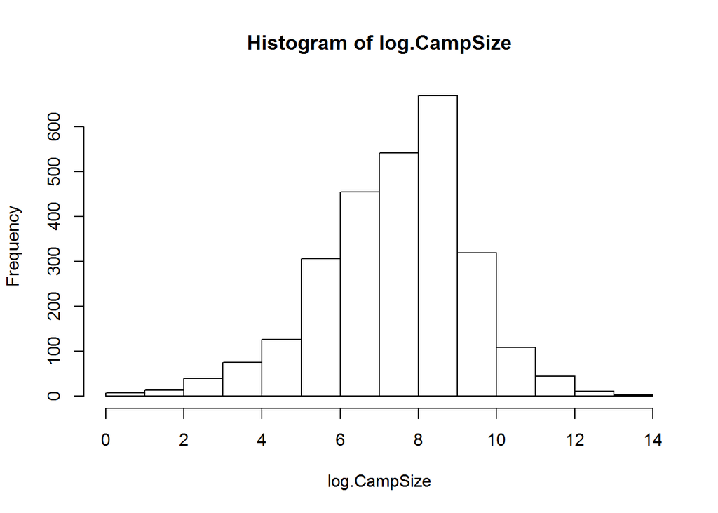

```r
##natural logarithm of the total species count per camp
foxyCamps=which(foxData$FlyingFoxesAbsent!=TRUE)
foxyCamps=totalFox[foxyCamps]
log.CampSize=log(foxyCamps)
#paste(totalFox,logCampSize)
#logCampSize
foxyCamps.length=length(foxyCamps)

##histogram of camp size logarithm
hist(log.CampSize)
```

2. [2 marks] Use bootstrapping to compute a 95% confidence interval for the mean logarithm of the total camp size for non-empty camps. Interpret your result.

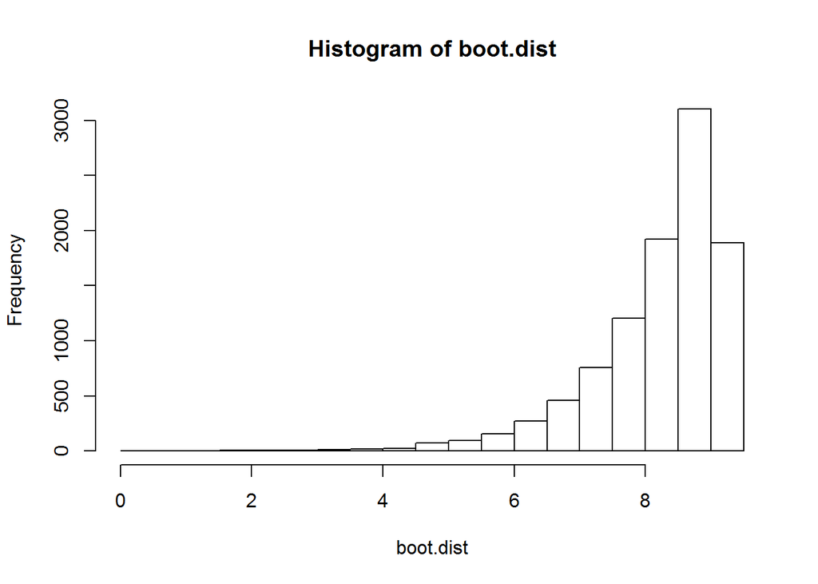

```r
##boot strap of mean camp size logarithm
##Generating a Bootstrap Distribution
b = 10000
boot.dist = rep(NA, b)
for (i in 1:b) {
boot.sample = sample(b, replace=TRUE)
boot.dist=log(boot.sample)
boot.dist[i]=mean(boot.dist)
sd(boot.dist)
}
hist(boot.dist)
```

## Part Three - Species Proportions

1. [2 marks] Compute the proportions of each species at each camp site and visualise them. Then compute the overall proportions of each species. Discuss your results.
2. [2 marks] Analyse whether the total camp size and the proportion of Little Red Flying Foxes are associated by testing at a signifcance level of 1% whether whether there is evidence that the correlation between the total size of a camp and the proportion of Little Red Flying Foxes in that camp is non-zero. Interpret your results.